# Richness2

LiaC

2018-09-19

# Species richness

## Load data and review summary statistics

Note we have 57 species levels, of which 10 are ‘unidentified …’ and 1 is our ‘0’ for empty nets. This leaves us with total richness of 46 species for both years and all habitats.

2016 has 39 species and 2017 has 36 species (code not shown), with some differences between years.  
In 2016 the following species were seen, but were NOT seen in 2017 (n = 10): coho, pink, white crappie, longfin smelt, whitespotted greenling, big skate, pacific tomcod, sand sole, kelp perch, walleye pollock  
In 2017 the following species were seen that were not present in 2016 (n = 7): steelhead, tiger rockfish, pacific sanddab, buffalo sculpin, kelp greenling, kelp poacher, redside shiner (note this was seen in 2016 but removed from analyses because the set was ranked as a success level of ‘1’ and repeated)

```r
all <- read.csv("/Users/Lia/Documents/Git/Fraser-salmon/all.data/all_clean.csv")  ### all catch by Species
library(plyr)

## Summary
levels(all$Species)
##  [1] "0"                          "Arrow goby"
##  [3] "Bay pipefish"               "Big skate"
##  [5] "Buffalo sculpin"            "Chinook"
##  [7] "Chum"                       "Coho"
##  [9] "Crescent gunnel"            "English sole"
## [11] "Herring"                    "Kelp greenling"
## [13] "Kelp perch"                 "Kelp poacher"
## [15] "Large scale sucker"         "Longfin smelt"
## [17] "Northern anchovy"           "Pacific sand lance"
## [19] "Pacific sanddab"            "Pacific tomcod"
## [21] "Peamouth chub"              "Penpoint gunnel"
## [23] "Pike minnow"                "Pile perch"
## [25] "Pink"                       "Plainfin midshipman"
## [27] "Prickly sculpin"            "Pumpkinseed"
## [29] "Redside shiner"             "River lamprey"
## [31] "Saddleback gunnel"          "Sand sole"
## [33] "Shiner surfperch"           "Snake prickleback"
## [35] "Sockeye"                    "Speckled sanddab"
## [37] "Staghorn sculpin"           "Starry flounder"
## [39] "Steelhead"                  "Surf smelt"
## [41] "Three-spined stickleback"   "Tidepool sculpin"
## [43] "Tiger rockfish"             "Tubesnout"
## [45] "Unidentified flatfish"      "Unidentified gadidae"
## [47] "Unidentified greenling"     "Unidentified gunnel"
## [49] "Unidentified larval fish"   "Unidentified larval fish 2"
## [51] "Unidentified salmonid"      "Unidentified sanddab"
## [53] "Unidentified sculpin"       "Unidentified smelt"
## [55] "Walleye pollock"            "White crappie"
## [57] "Whitespotted greenling"

### Aggregate by Species*site*day, including all parameters that might be of
### interest Start by counting all rows, note this includes each set (3
### replicates per site)
all <- count(all, c("Year", "J.date", "SIN_TIME", "round", "month", "Habitat",
    "Site", "Temp.surf", "DOmg.surf", "pH.surf", "Sal.surf", "Set", "Species"))
# Now sum by species*site*day
all.sp <- ddply(all, .(Year, J.date, SIN_TIME, round, month, Habitat, Site,
    Temp.surf, DOmg.surf, pH.surf, Sal.surf, Species), summarize, abund = sum(freq))
all.sp$abund[which(all.sp$Species == 0)] <- 0  #convert 0 counts back to 0s

## Total abundance:
sum(all.sp$abund)
## [1] 51143
# 2016 abundance:
sum(all.sp[which(all.sp$Year == "0"), ]$abund)
## [1] 33435
# 2017 abundance:
sum(all.sp[which(all.sp$Year == "1"), ]$abund)
## [1] 17708
```

### Aggregate the data to get non-rarified richness counts (exploratory)

All sites, all habitats. Not segregated by class. Pooled sets (seine hauls) per site per day. Unique counts of the number of species present at each site during each sampling event.

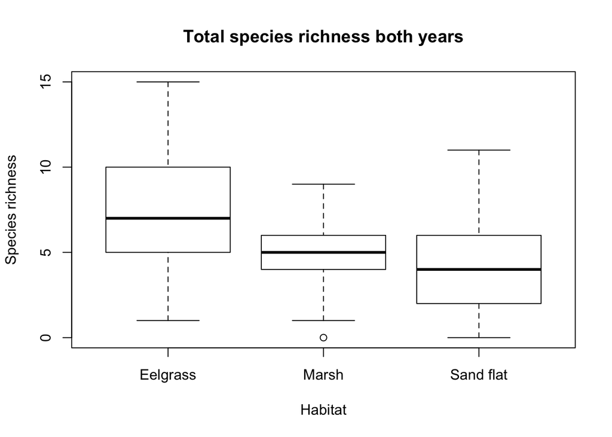

```r
## Richness without class now count the species and aggregate to get richness
## per site per day

#### Richness by Day*site
all.rich <- all.sp
#'count' all observation rows -- this gives count of 1 for each unique species per site*day, since we have tallied the species abund.
all.rich$freq = "1"
all.rich$freq[which(all.rich$Species == "0")] <- "0"  #convert 0 counts back to 0s
all.rich$abund[which(all.rich$Species == "0")] <- "0"  #convert 0 counts back to 0s
all.rich$freq <- as.numeric(all.rich$freq)  #convert richness (freq) to numeric
all.rich$abund <- as.numeric(all.rich$abund)  #convert abundance to numeric

# now sum up the richness counts by site*day, removing the species column
all.rich <- ddply(all.rich, .(SIN_TIME, round, month, Temp.surf, DOmg.surf,
    pH.surf, Sal.surf, Year, J.date, Habitat, Site), summarize, rich = sum(freq))

# Look at mean and SD of richness == the mean number of unique fish species
# hauled per site, per day (3 pooled sets) Note that we have 3 instances of
# 0 fish caught (with all sets pooled) at a site = 3 x empty nets. Our max
# richness per site in a day is 15 species.
summary(all.rich$rich)
##    Min. 1st Qu.  Median    Mean 3rd Qu.    Max.
##   0.000   3.000   5.000   5.467   7.000  15.000

plot(rich ~ Habitat, data = all.rich, ylab = "Species richness", main = "Total species richness both years")
```

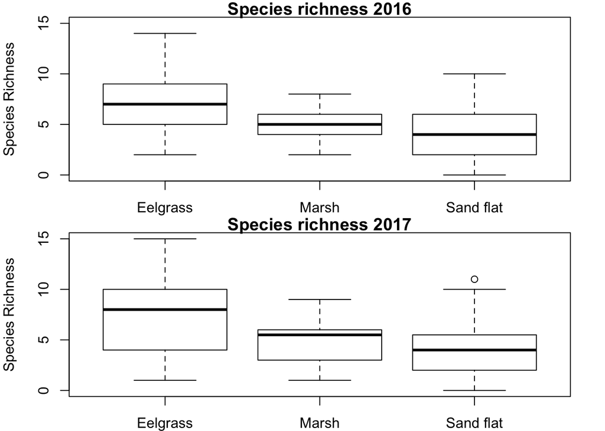

```r
par(mar = c(2, 4, 1, 2), mfrow = c(2, 1))
plot(rich ~ Habitat, ylab = "Species Richness", ylim = c(0, 15), main = "Species richness 2016",
    data = all.rich[which(all.rich$Year == "0"), ])
plot(rich ~ Habitat, ylab = "Species Richness", main = "Species richness 2017",
    data = all.rich[which(all.rich$Year == "1"), ])
```

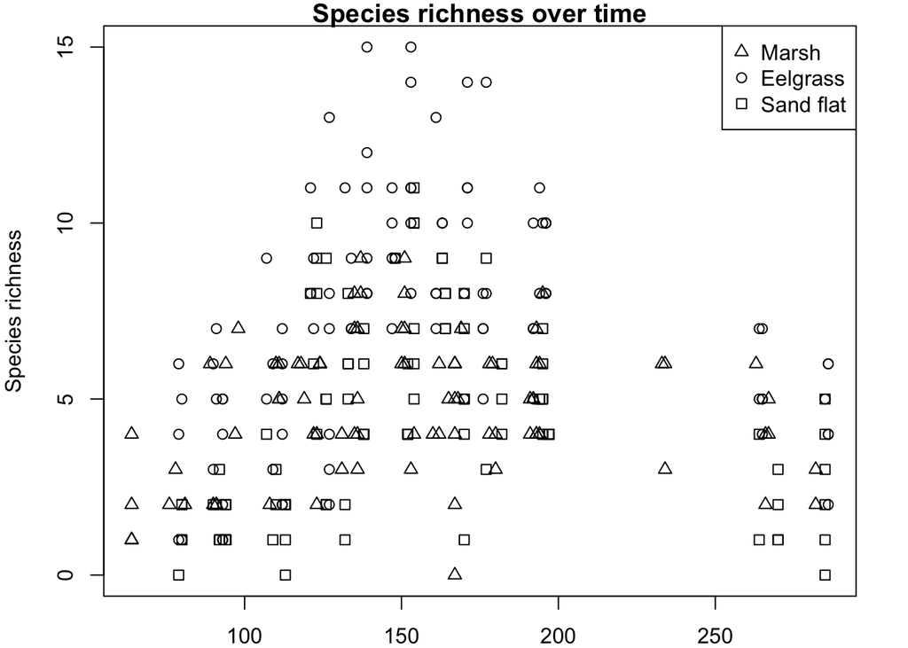

```r
## Re-factor data to order Marsh first for sensibility (currently Marsh is
## level 2, which puts it between eelgrass and sand flat in all plots and is
## nonsensical given that the marsh sites were beach seined)
all.rich2 <- all.rich
all.rich2$Habitat <- factor(all.rich$Habitat, levels = c("Marsh", "Eelgrass",
    "Sand flat"))
levels(all.rich2$Habitat)
## [1] "Marsh"     "Eelgrass"  "Sand flat"

par(mfrow = c(1, 1))
plot(rich ~ J.date, pch = c(2, 1, 0)[all.rich2$Habitat], ylab = "Species richness",
    xlab = "Julian day", main = "Species richness over time", data = all.rich2)
legend("topright", c("Marsh", "Eelgrass", "Sand flat"), pch = c(2, 1, 0))


#### Standardize all continuous variables so they are centered on the mean
#### install.packages('robustHD') install.packages('robustbase',
#### repos='http://R-Forge.R-project.org')
library(robustHD)
## Loading required package: ggplot2
## Loading required package: perry
## Loading required package: parallel
## Loading required package: robustbase
```

```r
# Use standardize function and then convert to numeric (from atomic vector)
all.rich2$s.temp <- as.numeric(standardize(all.rich2$Temp.surf, centerFun = mean,
    scaleFun = sd))
all.rich2$s.sal <- as.numeric(standardize(all.rich2$Sal.surf, centerFun = mean,
    scaleFun = sd))
all.rich2$s.do <- as.numeric(standardize(all.rich2$DOmg.surf, centerFun = mean,
    scaleFun = sd))
all.rich2$s.pH <- as.numeric(standardize(all.rich2$pH.surf, centerFun = mean,
    scaleFun = sd))
all.rich2$s.J.date <- as.numeric(standardize(all.rich2$J.date, centerFun = mean,
    scaleFun = sd))
### Add standardized parameter julian date squared in order to model J date -
### richness as quadratic relationship
all.rich2$j2 <- as.numeric(all.rich2$s.J.date^2)
```

# Rarefy

## **V1: Habitat** compare by habitat, including site_day as replicates for each habitat matrix

Script modified from Iacarella et al. 2018 (https://doi.org/10.1111/gcb.14090)

Sample based species richness rarefaction curves using iNEXT  
See https://besjournals.onlinelibrary.wiley.com/doi/full/10.1111/2041-210X.12613 for details on iNEXT

```r
library(iNEXT)
library(ggplot2)

species.full <- all.sp[, c("Year", "J.date", "month", "round", "Habitat", "Site",
    "Species", "abund")]

## Remove unidentified species and 0 species (empty sets) to reflect actual
## richness
species.full$abund[which(species.full$Species %in% ("0"))] <- NA
species.full$abund[which(species.full$Species %in% ("Unidentified smelt"))] <- NA
species.full$abund[which(species.full$Species %in% ("Unidentified sculpin"))] <- NA
species.full$abund[which(species.full$Species %in% ("Unidentified sanddab"))] <- NA
species.full$abund[which(species.full$Species %in% ("Unidentified salmonid"))] <- NA
species.full$abund[which(species.full$Species %in% ("Unidentified larval fish 2"))] <- NA
species.full$abund[which(species.full$Species %in% ("Unidentified larval fish"))] <- NA
species.full$abund[which(species.full$Species %in% ("Unidentified gunnel"))] <- NA
species.full$abund[which(species.full$Species %in% ("Unidentified greenling"))] <- NA
species.full$abund[which(species.full$Species %in% ("Unidentified gadidae"))] <- NA
species.full$abund[which(species.full$Species %in% ("Unidentified flatfish"))] <- NA

species.full <- na.omit(species.full)  #Now remove all rows that contain NA values, run species summary again to check all empty levels are correct
species.full$Species <- factor(species.full$Species)  ##drop unused species levels
head(species.full)  ## can see we have data in format of unique rows for each habitat, species, site observation by day (except removed day) - abundance represents # of individuals of that species at that site in all 3 sets.
```

```
##   Year J.date month round   Habitat Site            Species abund
## 1    0     92 March     2 Sand flat  SF2   Speckled sanddab     1
## 4    0     92 March     2 Sand flat  SF4       Bay pipefish     1
## 5    0     92 March     2 Sand flat  SF4    Starry flounder     1
## 6    0     92 March     2 Sand flat  SF4         Arrow goby     1
## 8    0     92 March     2 Sand flat  SF1 Pacific sand lance     1
## 9    0     92 March     2 Sand flat  SF3         Arrow goby     1
```

```r
## simplify data into species counts by habitat, site, and day
species <- species.full[, c("Year", "J.date", "Habitat", "Site", "Species",
    "abund")]

######## VERSION 1: HABITAT LEVEL COMPARISON Subset data into habitat categories
######## for analysis (spp counts (presence) are rows, sites are columns), and make
######## presence/absence matrix
Marsh <- subset(species, Habitat %in% c("Marsh"))
## Create year_day_site identifier to capture all independent sampling events
## (still 3 sets/day pooled)
Marsh$year_day_Site <- paste(Marsh$Year, Marsh$J.date, Marsh$Site)
# now can remove columns for Year, J.date, Habitat and Site
Marsh <- Marsh[, -c(1:4)]
Marsh.t <- as.data.frame.matrix(table(Marsh[c(1, 3)]))  #now have species ~ sampling event matrix, showing the # of days where each of these species has been present for each site (and 0s for those not counted). This is already simplified to presence/absence
head(Marsh.t)
```

```
##                 0 111 M3 0 117 M2 0 118 M1 0 119 M4 0 124 M3 0 124 M4
## Arrow goby             0        0        0        0        0        0
## Bay pipefish           0        0        0        0        0        0
## Big skate              0        0        0        0        0        0
## Buffalo sculpin        0        0        0        0        0        0
## Chinook                1        1        1        1        1        1
## Chum                   1        1        1        0        1        1
##                 0 131 M1 0 131 M2 0 135 M3 0 135 M4 0 136 M1 0 136 M2
## Arrow goby             0        0        0        0        0        0
## Bay pipefish           0        0        0        0        0        0
## Big skate              0        0        0        0        0        0
## Buffalo sculpin        0        0        0        0        0        0
## Chinook                1        1        1        1        1        1
## Chum                   0        1        0        0        1        0
##                 0 150 M4 0 151 M3 0 151 M5 0 153 M1 0 154 M2 0 160 M3
## Arrow goby             0        0        0        0        0        0
## Bay pipefish           0        0        0        0        0        0
## Big skate              0        0        0        0        0        0
## Buffalo sculpin        0        0        0        0        0        0
## Chinook                1        1        1        0        1        1
## Chum                   0        0        0        0        0        1
##                 0 162 M4 0 162 M5 0 165 M1 0 167 M2 0 167 M5 0 178 M3
## Arrow goby             0        0        0        0        0        0
## Bay pipefish           0        0        0        0        0        0
## Big skate              0        0        0        0        0        0
## Buffalo sculpin        0        0        0        0        0        0
## Chinook                1        1        1        1        1        0
## Chum                   0        0        0        0        0        0
##                 0 178 M4 0 179 M2 0 180 M1 0 180 M5 0 191 M3 0 191 M4
## Arrow goby             0        0        0        0        0        0
## Bay pipefish           0        0        0        0        0        0
## Big skate              0        0        0        0        0        0
## Buffalo sculpin        0        0        0        0        0        0
## Chinook                0        0        0        1        1        0
## Chum                   0        0        0        0        0        0
##                 0 193 M1 0 193 M5 0 195 M2 0 263 M1 0 266 M3 0 266 M4
## Arrow goby             0        0        0        0        0        0
## Bay pipefish           0        0        0        0        0        0
## Big skate              0        0        0        0        0        0
## Buffalo sculpin        0        0        0        0        0        0
```

[output cut: 43 more lines]

```
## Chum                   0        0        0        0        0        0
##                 1 233 M1 1 234 M2 1 234 M5 1 64 M1 1 64 M2 1 64 M3 1 64 M5
## Arrow goby             0        0        0       0       0       0       0
## Bay pipefish           0        0        0       0       0       0       0
## Big skate              0        0        0       0       0       0       0
## Buffalo sculpin        0        0        0       0       0       0       0
## Chinook                0        0        0       0       0       0       1
## Chum                   0        0        0       0       0       0       1
##                 1 76 M3 1 78 M1 1 81 M5 1 90 M5 1 91 M2
## Arrow goby            0       0       0       0       0
## Bay pipefish          0       0       0       0       0
## Big skate             0       0       0       0       0
## Buffalo sculpin       0       0       0       0       0
## Chinook               1       1       1       1       1
## Chum                  1       1       0       0       1
```

```r
## Eelgrass
Eelgrass <- subset(species, Habitat %in% c("Eelgrass"))
Eelgrass$year_day_Site <- paste(Eelgrass$Year, Eelgrass$J.date, Eelgrass$Site)
Eelgrass <- Eelgrass[, -c(1:4)]
Eelgrass.t <- as.data.frame.matrix(table(Eelgrass[c(1, 3)]))

## Sand flat
Sandflat <- subset(species, Habitat %in% c("Sand flat"))
Sandflat$year_day_Site <- paste(Sandflat$Year, Sandflat$J.date, Sandflat$Site)
Sandflat <- Sandflat[, -c(1:4)]
Sandflat.t <- as.data.frame.matrix(table(Sandflat[c(1, 3)]))

## Make list of matrices (one for each habitat type)
my.list <- list(Marsh.t, Eelgrass.t, Sandflat.t)
names(my.list) <- c("Marsh", "Eelgrass", "Sandflat")
str(my.list, list.len = 10)
```

```
## List of 3
##  $ Marsh   :'data.frame':    46 obs. of  84 variables:
##   ..$ 0 111 M3: int [1:46] 0 0 0 0 1 1 1 0 0 0 ...
##   ..$ 0 117 M2: int [1:46] 0 0 0 0 1 1 0 0 0 0 ...
##   ..$ 0 118 M1: int [1:46] 0 0 0 0 1 1 0 0 0 0 ...
##   ..$ 0 119 M4: int [1:46] 0 0 0 0 1 0 0 0 0 0 ...
##   ..$ 0 124 M3: int [1:46] 0 0 0 0 1 1 0 0 0 0 ...
##   ..$ 0 124 M4: int [1:46] 0 0 0 0 1 1 0 0 0 0 ...
##   ..$ 0 131 M1: int [1:46] 0 0 0 0 1 0 0 0 0 0 ...
##   ..$ 0 131 M2: int [1:46] 0 0 0 0 1 1 0 0 0 0 ...
##   ..$ 0 135 M3: int [1:46] 0 0 0 0 1 0 0 0 0 0 ...
##   ..$ 0 135 M4: int [1:46] 0 0 0 0 1 0 0 0 0 0 ...
##   .. [list output truncated]
##  $ Eelgrass:'data.frame':    46 obs. of  99 variables:
##   ..$ 0 107 E1: int [1:46] 0 1 0 0 0 0 0 0 0 0 ...
##   ..$ 0 107 E3: int [1:46] 0 1 0 0 0 0 0 1 0 0 ...
##   ..$ 0 109 E4: int [1:46] 0 1 0 0 0 0 0 1 0 0 ...
##   ..$ 0 109 E5: int [1:46] 0 1 0 0 0 0 0 0 0 0 ...
##   ..$ 0 121 E2: int [1:46] 0 1 0 0 1 1 0 1 0 0 ...
##   ..$ 0 121 E3: int [1:46] 0 1 0 0 1 0 0 0 0 0 ...
##   ..$ 0 122 E4: int [1:46] 0 1 0 0 1 0 0 0 0 0 ...
##   ..$ 0 122 E5: int [1:46] 0 1 0 0 1 0 0 0 0 0 ...
##   ..$ 0 132 E2: int [1:46] 0 1 0 0 0 0 0 1 0 1 ...
##   ..$ 0 134 E3: int [1:46] 0 1 0 0 0 0 0 0 0 0 ...
##   .. [list output truncated]
##  $ Sandflat:'data.frame':    46 obs. of  99 variables:
##   ..$ 0 107 SF6: int [1:46] 0 0 0 0 0 0 0 0 0 0 ...
##   ..$ 0 109 SF5: int [1:46] 0 0 0 0 1 0 0 0 0 0 ...
##   ..$ 0 110 SF1: int [1:46] 1 0 0 0 0 0 0 0 0 0 ...
##   ..$ 0 110 SF2: int [1:46] 1 0 0 0 0 0 0 0 0 0 ...
##   ..$ 0 121 SF6: int [1:46] 0 0 0 0 1 0 0 0 1 0 ...
##   ..$ 0 122 SF5: int [1:46] 0 0 0 0 1 0 0 1 0 0 ...
##   ..$ 0 123 SF1: int [1:46] 0 0 0 0 1 1 0 0 0 0 ...
##   ..$ 0 123 SF2: int [1:46] 0 1 0 0 0 0 0 0 0 0 ...
##   ..$ 0 123 SF3: int [1:46] 1 1 0 0 1 0 0 0 0 0 ...
##   ..$ 0 123 SF4: int [1:46] 1 1 0 0 1 0 0 0 0 0 ...
##   .. [list output truncated]
```

```r
## Run rarefaction on matrix list 1 using incidence aggregation

t <- seq(1, 180, by = 1)
Rich.rar <- iNEXT(my.list, q = c(0), datatype = "incidence_raw", size = t, se = TRUE,
    conf = 0.95, nboot = 999)
Rich.rar$DataInfo
```

```
##       site  T   U S.obs     SC Q1 Q2 Q3 Q4 Q5 Q6 Q7 Q8 Q9 Q10
## 1    Marsh 84 386    19 0.9898  4  2  1  1  1  0  0  2  0   0
## 2 Eelgrass 99 697    37 0.9901  7  4  2  1  0  2  0  1  0   1
## 3 Sandflat 99 386    22 0.9975  1  2  1  0  0  1  3  0  3   1
```

```r
#'For incidence data, the list $DataInfo includes the reference sample size (T), observed species richness (S.obs), total number of incidences (U), a sample coverage estimate (SC), and the first ten incidence frequency counts (Q1‐Q10).'

Rich.rar$iNextEst
```

```
## $Marsh
##       t       method order     qD qD.LCL qD.UCL    SC SC.LCL SC.UCL
## 1     1 interpolated     0  4.595  4.290  4.900 0.542  0.503  0.580
## 2     2 interpolated     0  6.701  6.320  7.082 0.737  0.705  0.770
## 3     3 interpolated     0  7.909  7.459  8.358 0.822  0.795  0.849
## 4     4 interpolated     0  8.727  8.206  9.247 0.865  0.842  0.888
## 5     5 interpolated     0  9.345  8.754  9.936 0.890  0.870  0.911
## 6     6 interpolated     0  9.849  9.190 10.508 0.906  0.888  0.925
## 7     7 interpolated     0 10.279  9.555 11.003 0.917  0.901  0.934
## 8     8 interpolated     0 10.658  9.874 11.443 0.926  0.910  0.941
## 9     9 interpolated     0 11.000 10.158 11.842 0.932  0.917  0.947
## 10   10 interpolated     0 11.313 10.416 12.210 0.937  0.923  0.951
## 11   11 interpolated     0 11.603 10.654 12.551 0.941  0.928  0.955
## 12   12 interpolated     0 11.873 10.874 12.871 0.945  0.932  0.958
## 13   13 interpolated     0 12.126 11.080 13.172 0.948  0.935  0.961
```

[output cut: 533 more lines]

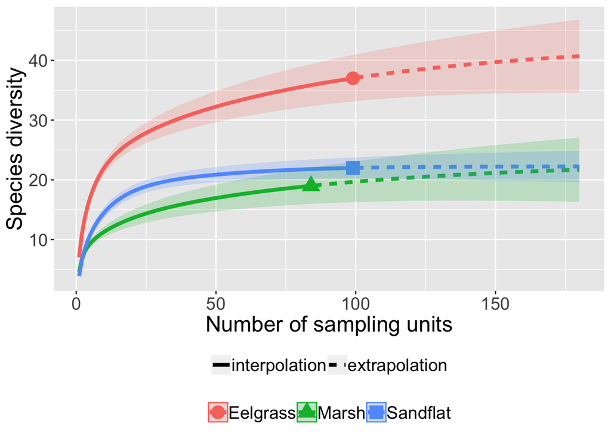

```r
ggiNEXT(Rich.rar, type = 1)
```

```r
# this looks like what I would expect, with eelgrass significantly higher,
# marsh lowest and sand flat low but higher than marsh.

## Save results for graph
f <- fortify(Rich.rar, type = 1)
write.csv(f, "/Users/Lia/Documents/Git/Fraser-salmon/all.data/Rich.rar.csv")
f$site <- factor(f$site, levels = unique(f$site))
f.point <- f[which(f$method == "observed"), ]
f.line <- f[which(f$method != "observed"), ]
f.line$method <- factor(f.line$method, c("interpolated", "extrapolated"), c("interpolation",
    "extrapolation"))
```

### FINAL PLOT #1, Habitat comparison - black and white

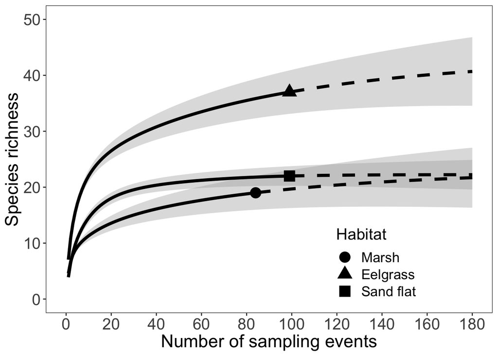

```r
## Plot pretty
gg.rich1 <- ggplot(f, aes(x = x, y = y, shape = site)) + geom_ribbon(aes(ymin = y.lwr,
    ymax = y.upr), fill = "gray68", alpha = 0.4) + geom_point(aes(shape = site),
    size = 5, data = f.point, colour = "black") + scale_shape_manual(values = c(16,
    17, 15), breaks = c("Marsh", "Eelgrass", "Sandflat"), labels = c("Marsh",
    "Eelgrass", "Sand flat"), name = "Habitat") + geom_line(aes(linetype = method),
    lwd = 1.5, data = f.line, colour = "black") + scale_linetype_manual(values = c("solid",
    "dashed"), breaks = c("interpolation", "extrapolation"), labels = c("Interpolation",
    "Extrapolation"), name = "Method", guide = FALSE) + labs(x = "Number of sampling events",
    y = "Species richness") + theme_bw() + scale_y_continuous(limits = c(0,
    50), breaks = seq(0, 50, by = 10)) + scale_x_continuous(limits = c(0, 180),
    breaks = seq(0, 180, by = 20)) + theme(axis.line.x = element_line(color = "black",
    size = 0.5), axis.line.y = element_line(color = "black", size = 0.5)) +
    theme(axis.text.x = element_text(size = 16), axis.title.x = element_text(size = 18),
        axis.title.y = element_text(angle = 90, size = 18), axis.text.y = element_text(size = 16),
        legend.position = c(0.8, 0.08), legend.justification = c(0.8, 0.2),
        legend.text = element_text(size = 14), legend.title = element_text(size = 16),
        legend.key = element_blank(), panel.grid.minor = element_blank(), panel.grid.major = element_blank())
gg.rich1
```

```r
# ggsave('/Users/Lia/Documents/Git/Fraser-salmon/Ch1.Seasonal_diversity/final.figures/RichnessRareHabitat.pdf')
```

### FINAL PLOT #1.2, Habitat comparison - colour

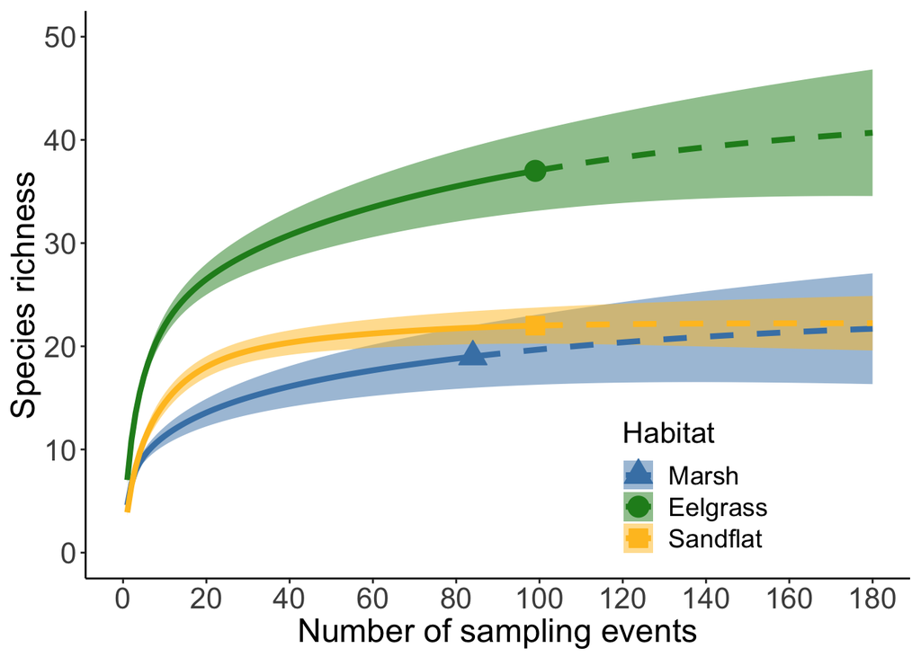

### FINAL PLOT 1.2, panel 0, above habitat plot reduced in size to fit with season panel plots

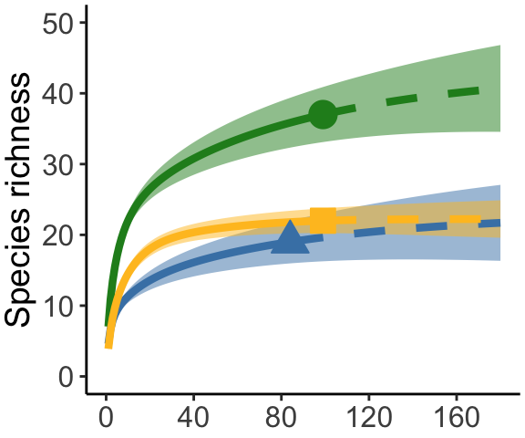

## **V2: Season** compare by Season, Habitat; split into plot for each habitat

```r
#### Separate into data frames by Season*Habitat
species.full$Site_day_year <- paste(species.full$Site, species.full$J.date,
    species.full$Year)  #create new site_day_year label to identify each independent sampling event (sets still pooled).

## Spring
Spring <- subset(species.full, month %in% c("March", "April"))  ##Note narrowed the aggregation to site_day_year as opposed to site_round, which gives more data points per season for a smoother curve

Spring <- Spring[, -c(1:4, 6)]  #remove columns for year, jday, month, round, site
# Marsh
MarshSpring <- subset(Spring, Habitat %in% c("Marsh"))
MarshSpring <- MarshSpring[, -1]  #remove column for Hab
MarshSp.t <- as.data.frame.matrix(table(MarshSpring[c(1, 3)]))  #now have species ~ site_day_year matrix, showing the # of sampling events where each of these species has been present for each site each round (and 0s for those not counted), across both years.
# This has already been simplified to counts per sampling event, so is
# presence/absence (1s and 0s)
head(MarshSp.t)
##                 M1 108 1 M1 118 0 M1 122 1 M1 131 0 M1 64 1 M1 78 1
## Arrow goby             0        0        0        0       0       0
## Bay pipefish           0        0        0        0       0       0
## Big skate              0        0        0        0       0       0
## Buffalo sculpin        0        0        0        0       0       0
## Chinook                1        1        1        1       0       1
## Chum                   1        1        1        0       0       1
##                 M1 97 0 M2 110 1 M2 117 0 M2 123 1 M2 131 0 M2 64 1
## Arrow goby            0        0        0        0        0       0
## Bay pipefish          0        0        0        0        0       0
## Big skate             0        0        0        0        0       0
## Buffalo sculpin       0        0        0        0        0       0
## Chinook               1        1        1        1        1       0
## Chum                  1        1        1        1        1       0
##                 M2 91 1 M2 94 0 M3 111 0 M3 111 1 M3 124 0 M3 124 1
## Arrow goby            0       0        0        0        0        0
## Bay pipefish          0       0        0        0        0        0
## Big skate             0       0        0        0        0        0
## Buffalo sculpin       0       0        0        0        0        0
## Chinook               1       1        1        1        1        1
## Chum                  1       1        1        1        1        1
##                 M3 64 1 M3 76 1 M3 89 0 M4 111 1 M4 119 0 M4 124 0
## Arrow goby            0       0       0        0        0        0
## Bay pipefish          0       0       0        0        0        0
## Big skate             0       0       0        0        0        0
## Buffalo sculpin       0       0       0        0        0        0
## Chinook               0       1       1        1        1        1
## Chum                  0       1       1        0        0        1
##                 M4 124 1 M4 98 0 M5 110 1 M5 123 1 M5 64 1 M5 81 1 M5 90 1
## Arrow goby             0       0        0        0       0       0       0
## Bay pipefish           0       0        0        0       0       0       0
## Big skate              0       0        0        0       0       0       0
## Buffalo sculpin        0       0        0        0       0       0       0
## Chinook                1       1        1        1       1       1       1
## Chum                   1       1        1        1       1       0       0

# Eelgrass
EGSpring <- subset(Spring, Habitat %in% c("Eelgrass"))
EGSpring <- EGSpring[, -1]
EGSp.t <- as.data.frame.matrix(table(EGSpring[c(1, 3)]))

# Sand flat
SFSpring <- subset(Spring, Habitat %in% c("Sand flat"))
SFSpring <- SFSpring[, -1]
SFSp.t <- as.data.frame.matrix(table(SFSpring[c(1, 3)]))

## Summer
Summer <- subset(species.full, month %in% c("May", "June", "July", "August"))

Summer <- Summer[, -c(1:4, 6)]  #remove columns for year, jday, month, round, site
# Marsh
MarshSummer <- subset(Summer, Habitat %in% c("Marsh"))
MarshSummer <- MarshSummer[, -1]
MarshSu.t <- as.data.frame.matrix(table(MarshSummer[c(1, 3)]))

# Eelgrass
EGSummer <- subset(Summer, Habitat %in% c("Eelgrass"))
EGSummer <- EGSummer[, -1]
EGSu.t <- as.data.frame.matrix(table(EGSummer[c(1, 3)]))

# Sand flat
SFSummer <- subset(Summer, Habitat %in% c("Sand flat"))
SFSummer <- SFSummer[, -1]
SFSu.t <- as.data.frame.matrix(table(SFSummer[c(1, 3)]))


## Fall (note 2016 only; not all marsh sites visited in October due to
## weather - will be limiting factor for sample size)
Fall <- subset(species.full, month %in% c("September", "October"))

Fall <- Fall[, -c(1:4, 6)]
# Marsh
MarshFall <- subset(Fall, Habitat %in% c("Marsh"))
MarshFall <- MarshFall[, -1]
MarshF.t <- as.data.frame.matrix(table(MarshFall[c(1, 3)]))

# Eelgrass
EGFall <- subset(Fall, Habitat %in% c("Eelgrass"))
EGFall <- EGFall[, -1]
EGF.t <- as.data.frame.matrix(table(EGFall[c(1, 3)]))

# Sand flat
SFFall <- subset(Fall, Habitat %in% c("Sand flat"))
SFFall <- SFFall[, -1]
SFF.t <- as.data.frame.matrix(table(SFFall[c(1, 3)]))


## Make list of matrices (one for each habitat type) MARSH
my.listm <- list(MarshSp.t, MarshSu.t, MarshF.t)
names(my.listm) <- c("Marsh Early Spring", "Marsh Summer", "Marsh Fall")

## EELGRASS
my.listeg <- list(EGSp.t, EGSu.t, EGF.t)
names(my.listeg) <- c("Eelgrass Early Spring", "Eelgrass Summer", "Eelgrass Fall")

## SANDFLAT
my.listsf <- list(SFSp.t, SFSu.t, SFF.t)
names(my.listsf) <- c("Sandflat Early Spring", "Sandflat Summer", "Sandflat Fall")
```

### FINAL PLOT 2, panel 1. Season comparison, broken into habitats: Marsh

Note “For incidence data, the list $DataInfo includes the reference sample size (T), observed species richness (S.obs), total number of incidences (U), a sample coverage estimate (SC), and the first ten incidence frequency counts (Q1‐Q10).”

CAN SEE MUCH LOWER T AND U FOR MARSH IN FALL – set size limits to 1:75 in order to make graph look comparable.

```
##                 site  T   U S.obs     SC Q1 Q2 Q3 Q4 Q5 Q6 Q7 Q8 Q9 Q10
## 1 Marsh Early Spring 31 128    12 0.9773  3  0  0  1  0  1  0  1  0   0
## 2       Marsh Summer 46 233    14 0.9918  2  2  0  0  1  1  0  1  0   1
## 3         Marsh Fall  7  25     9 0.8629  4  2  0  1  0  1  1  0  0   0
```

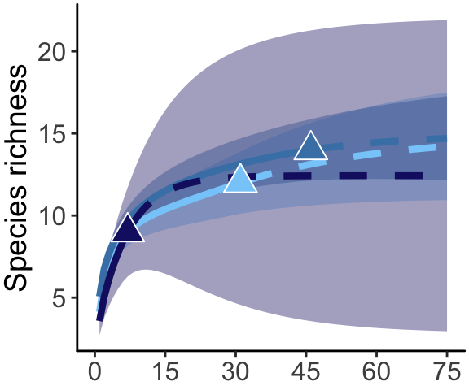

**Can see for marsh that season is not significantly different.** Most apparent is # of sampling events between seasons, which is highest in summer (May - Aug) and lowest in fall (Sept, Oct). When we look at the comparable point (sample size=7, for fall), the richness values across seasons are virtually identical.

### FINAL PLOT 2, panel 2, Season comparison, broken into habitats: Eelgrass

```
##                    site  T   U S.obs     SC Q1 Q2 Q3 Q4 Q5 Q6 Q7 Q8 Q9 Q10
## 1 Eelgrass Early Spring 35 161    25 0.9641  6  4  3  3  2  0  2  0  0   1
## 2       Eelgrass Summer 52 477    32 0.9877  6  3  3  0  1  0  0  0  2   1
## 3         Eelgrass Fall 12  59    17 0.8925  7  4  0  2  0  1  1  0  0   0
```

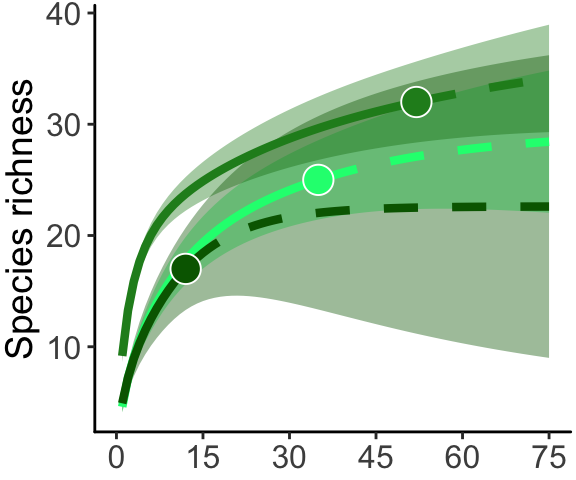

**Note that for eelgrass, summer is significantly higher** than spring and fall at the point of comparison (fall, #sampling events = 12). Summer now includes May. Fall is lowest

### FINAL PLOT 2, panel 3, Season comparison, broken into habitats: Sand flat

```
##                    site  T   U S.obs     SC Q1 Q2 Q3 Q4 Q5 Q6 Q7 Q8 Q9 Q10
## 1 Sandflat Early Spring 36  97    20 0.9393  6  2  2  1  2  1  1  0  0   1
## 2       Sandflat Summer 54 264    20 0.9928  2  3  1  0  1  3  0  2  1   1
## 3         Sandflat Fall  9  25    10 0.9100  3  4  1  0  1  1  0  0  0   0
```

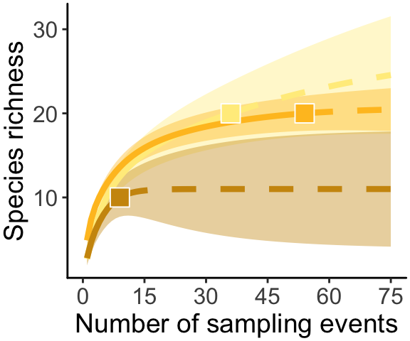

**Despite appearing different, with spring at highest richness, there is no significant difference between seasons for sand flat**. Similarly to eelgrass, the summer plateaus much more quickly, indicating more new spp encountered each sample during the spring months (March, April) vs the summer months (May,June, July, August(2017)). Limiting (fall) sample size is 9.

## Final combined figure with panels from fig 1 and fig 2 combined for seasonal richness by habitat

Can see that summer is significantly higher in eelgrass, higher but not significant in marsh, and that spring is higher but not significant in sand flat.

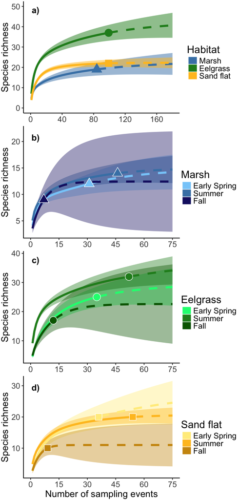

# Original code from Josie Iacarella

```r
# Original code from Josie

## Sample-size based rarefaction using incidence based data


## Subset data into habitat categories for analysis (spp counts (presence)
## are rows, sites are columns), and make presence/absence matrix
## High<-subset(Reg.simple,Dist == 'high') High<-High[,-1] High.t<-t(High)
## colnames(High.t) = High.t[1, ] # the first row will be the header High.t =
## High.t[-1, ] High.n <- apply(High.t,2,as.numeric) High.pres <-
## ifelse(High.n > 0, 1, 0) #make matrix pres/abs High.pres <-
## apply(High.pres,2,as.integer) rownames(High.pres)<-rownames(High.t)

# Med<-subset(Reg.simple,Dist == 'medium') Med<-Med[,-1] Med.t<-t(Med)
# colnames(Med.t) = Med.t[1, ] # the first row will be the header Med.t =
# Med.t[-1, ] Med.n <- apply(Med.t,2,as.numeric) Med.pres <- ifelse(Med.n >
# 0, 1, 0) #make matrix pres/abs Med.pres <- apply(Med.pres,2,as.integer)
# rownames(Med.pres)<-rownames(Med.t)

# Low<-subset(Reg.simple,Dist == 'low') Low<-Low[,-1] Low.t<-t(Low)
# colnames(Low.t) = Low.t[1, ] # the first row will be the header Low.t =
# Low.t[-1, ] Low.n <- apply(Low.t,2,as.numeric) Low.pres <- ifelse(Low.n >
# 0, 1, 0) #make matrix pres/abs Low.pres <- apply(Low.pres,2,as.integer)
# rownames(Low.pres)<-rownames(Low.t)

## Make list of matrices (one for each disturbance category)
## my.list<-sapply(list(set1,set2), identity, simplify='array') my.list[[1]]
## <- Low.pres my.list[[2]] <- Med.pres my.list[[3]] <- High.pres

# my.list<-list(Low.pres,Med.pres,High.pres)
# names(my.list)<-c('Low','Med','High') str(my.list)

## Run rarefaction on matrix list Reg.rar<-iNEXT(my.list,datatype =
## 'incidence_raw',endpoint=150,nboot = 999)

# ggiNEXT(Reg.rar)

## Save results for graph df<-fortify(Reg.rar,type=1) df.point <-
## df[which(df$method=='observed'),] df.line <-
## df[which(df$method!='observed'),] df.line$method <- factor(df.line$method,
## c('interpolated', 'extrapolated'), c('interpolation', 'extrapolation'))

## Plot Appendix S2, FigS4 gg.rich<- ggplot(df, aes(x=x,y=y,shape=site)) +
## geom_ribbon(aes(ymin=y.lwr, ymax=y.upr), fill='gray68', alpha=0.7) +
## geom_point(aes(shape=site), size=5, data=df.point, colour='black') +
## scale_shape_manual(values=c(15,16,17),breaks=c('Low','Med','High'),labels=c('Low','Medium','High'),
## name='Anthropogenic disturbance') + geom_line(aes(linetype=method),
## lwd=1.5, data=df.line, colour='black') +
## scale_linetype_manual(values=c('solid','dashed'),breaks=c('interpolation','extrapolation'),labels=c('Interpolation','Extrapolation'),name='Method',guide=FALSE)
## + labs(x='Number of sites', y='Species richness') + theme_bw() +
## scale_y_continuous(limits=c(0,80),breaks=seq(0,80,by=20)) +
## scale_x_continuous(limits=c(0,150),breaks=seq(0,150,by=50)) +
## theme(axis.line.x = element_line(color='black', size = 0.5), axis.line.y =
## element_line(color='black', size = 0.5)) +
## theme(axis.text.x=element_text(size=16),
## axis.title.x=element_text(size=18),
## axis.title.y=element_text(angle=90,size=18),
## axis.text.y=element_text(size=16),
## legend.position=c(.8,0.2),legend.justification=c(.8,.2),
## legend.text=element_text(size=14), legend.title=element_text(size=16),
## legend.key=element_blank(),
## panel.grid.minor=element_blank(),panel.grid.major=element_blank()) gg.rich
```